# Biomass chane at different levels of predation

Faith Jones

16 June 2017

Here i present the mixed model results for change in biomass of predators. There are three levels of predation: Wide (group 2 and 3 species), Middle (group2) and Narrow(Hoplias and Crenicichla). Only teh data from July/august is incuded so I could use the 2016 data. Also the survey eatken in 2010 is removed sure to sampling differences.

# Narrow level predation definition

Here is the raw plot of predator biomass agaist time, and the plot of log2 biomass against time. There is a lot of variability.

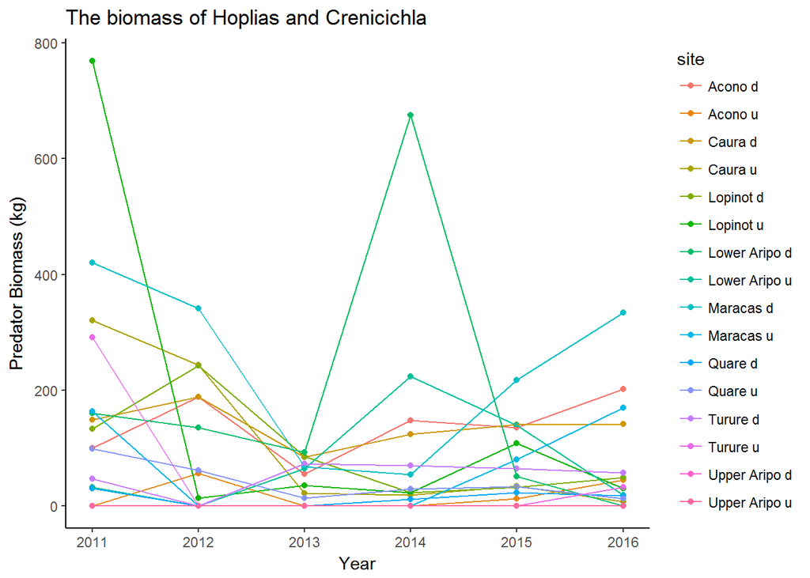

```r
BioPlot <- ggplot(FishDataTot, aes(x = Year, y = BiomassSum, col = site, group = site))
BioPlot + geom_point() +
    geom_line() +
    theme_classic() +
    labs(title="The biomass of Hoplias and Crenicichla", y = "Predator Biomass (kg)")
```

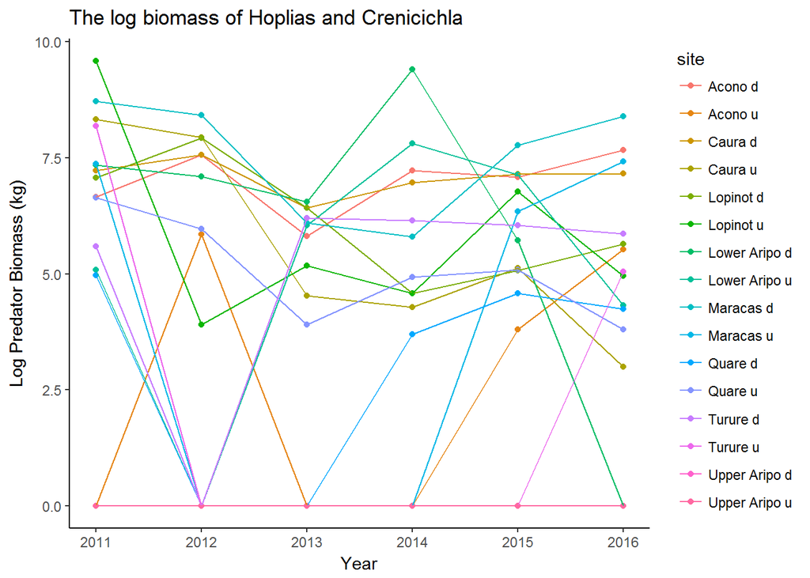

```r
BioPlotLog <- ggplot(FishDataTot, aes(x = Year, y = LogBiomass, col = site, group = site))
BioPlotLog + geom_point() +
    geom_line() +
    theme_classic() +
    labs(title="The log biomass of Hoplias and Crenicichla", y = "Log Predator Biomass (kg)")
```

Next is the mixed model results and plot of slopes of the sites

```r
bioMLog <- lmer(LogBiomass ~ meanCentredYear + (meanCentredYear|site), data = FishDataTot)
summary(bioMLog)
```

```
## Linear mixed model fit by REML ['lmerMod']
## Formula: LogBiomass ~ meanCentredYear + (meanCentredYear | site)
##    Data: FishDataTot
##
## REML criterion at convergence: 455.3
##
## Scaled residuals:
##      Min       1Q   Median       3Q      Max
## -2.47947 -0.49056  0.00353  0.53203  2.57602
##
## Random effects:
##  Groups   Name            Variance Std.Dev. Corr
##  site     (Intercept)     4.77104  2.1843
##           meanCentredYear 0.02486  0.1577   -1.00
##  Residual                 4.89539  2.2126
## Number of obs: 96, groups:  site, 16
##
## Fixed effects:
##                 Estimate Std. Error t value
## (Intercept)      4.46117    0.59092   7.550
## meanCentredYear -0.07836    0.13798  -0.568
##
## Correlation of Fixed Effects:
##             (Intr)
## meanCntrdYr -0.264
```

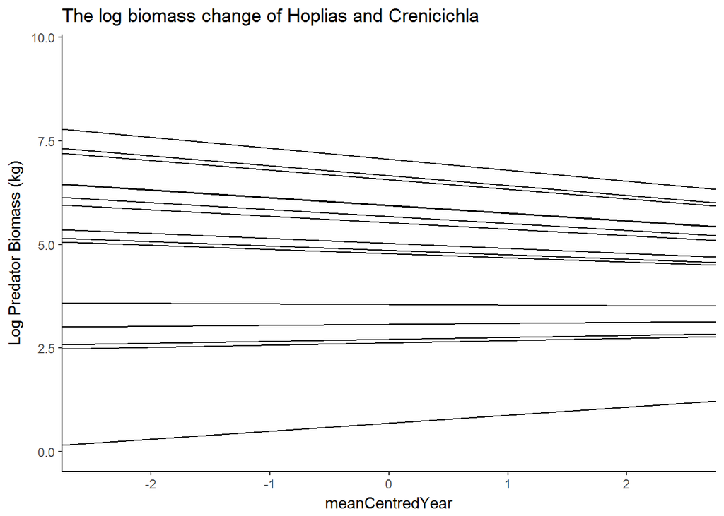

```r
#plot slopes of sites
bioMLog_Lines <- coef(bioMLog )$site[c(1:2)] # get slope and intercept of each line in model 3
names(bioMLog_Lines) <- c("intercept", "slope")

m3.plotb <- ggplot(data = FishDataTot, aes(x = meanCentredYear, y = LogBiomass)) # plot of model with varying intercept but not slope, but only main slope shown
m3.plotb + geom_blank() +
    theme_classic() +
    geom_abline(slope =bioMLog_Lines$slope, intercept = bioMLog_Lines$intercept) +
    labs(title="The log biomass change of Hoplias and Crenicichla", y = "Log Predator Biomass (kg)")
```

below is the plot not suing the mixed model results. It sies an lm function, and colours lines based on mean predation ranking

```r
head(FishDataTot)
```

```
##      site Year BiomasSiteSum BiomassSum meanYear meanCentredYear
## 1 Acono d 2011       1572.66       99.7   2013.5            -2.5
## 2 Acono d 2012        870.00      188.4   2013.5            -1.5
## 3 Acono d 2013       1599.30       55.0   2013.5            -0.5
## 4 Acono d 2014       1589.12      148.0   2013.5             0.5
## 5 Acono d 2015       1253.90      135.0   2013.5             1.5
## 6 Acono d 2016       1900.55      202.0   2013.5             2.5
##   LogBiomass
## 1   6.653920
## 2   7.565293
## 3   5.807355
## 4   7.219169
## 5   7.087463
## 6   7.665336
```

```r
predOrder <- data.frame(FishDataTot %>% #get the order of which sites are highest predation for plotting
  group_by(site) %>%
  summarise(meanbio = mean(BiomassSum)) %>%
  arrange(meanbio)%>%
  mutate(orderbio = c(1:16)))

plotNBioData <- merge(FishDataTot, predOrder, by = "site")

plotNBioData  <- plotNBioData[order(plotNBioData$orderbio),]
plotNBioData$reoderedSite <- reorder(plotNBioData$site, plotNBioData$orderbio)

getPalette <-  colorRampPalette(c("blue", "red"))
getPalette(16)
```

```
##  [1] "#0000FF" "#1100EE" "#2200DD" "#3300CC" "#4400BB" "#5500AA" "#660099"
##  [8] "#770088" "#880077" "#990066" "#AA0055" "#BB0044" "#CC0032" "#DD0021"
## [15] "#EE0010" "#FF0000"
```

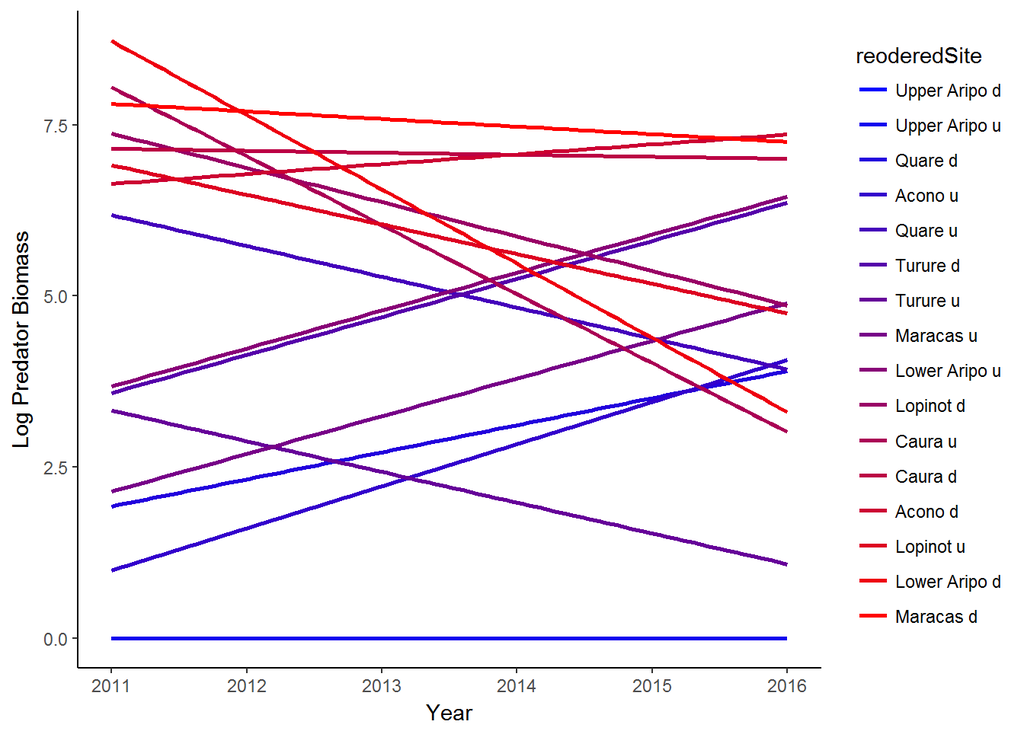

```r
NarrowAdundance <- ggplot(aes(x = Year, y = LogBiomass, colour = reoderedSite ),data = plotNBioData)
NarrowAdundance +
  geom_smooth(se = FALSE, method = "lm")+
    theme_classic()+
    labs(y = "Log Predator Biomass")   +
  scale_colour_manual(values = getPalette(16))
```

# Middle level predation definition

Here is the raw plot of predator biomass agaist time, and the plot of log2 biomass against time, for middel predation. There is a lot of variability.

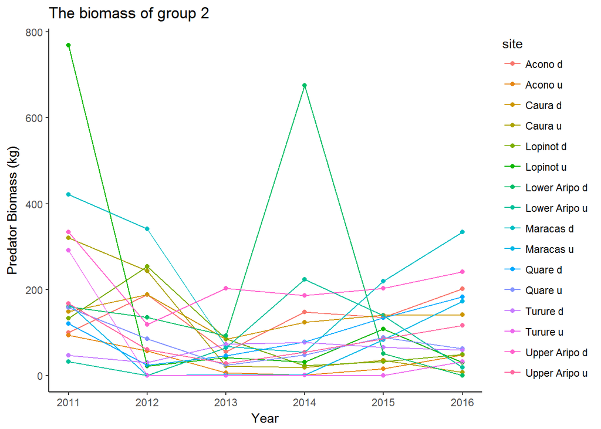

```r
BioPlotm <- ggplot(FishDataTotm, aes(x = Year, y = BiomassSum, col = site, group = site))
BioPlotm + geom_point() +
    geom_line() +
    theme_classic() +
    labs(title="The biomass of group 2", y = "Predator Biomass (kg)")
```

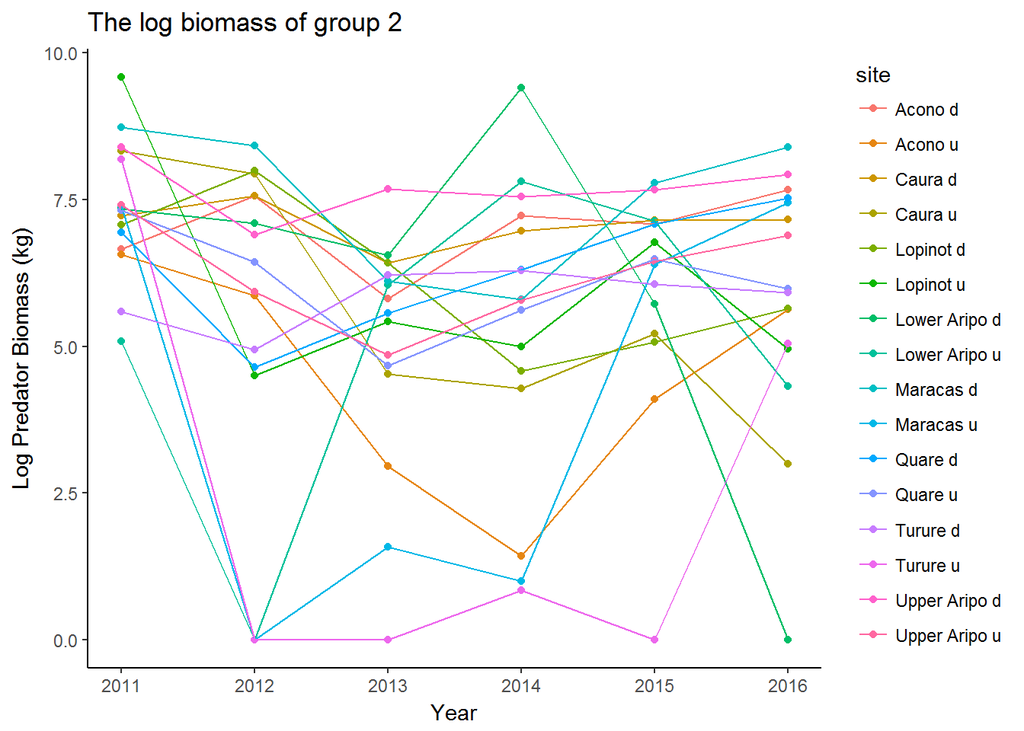

```r
BioPlotLogm <- ggplot(FishDataTotm, aes(x = Year, y = LogBiomass, col = site))
BioPlotLogm + geom_point() +
    geom_line() +
    theme_classic() +
    labs(title="The log biomass of group 2", y = "Log Predator Biomass (kg)")
```

Mixed model results and plot of slopes of the sites (Middle)

```r
bioMLogm <- lmer(LogBiomass ~ meanCentredYear + (meanCentredYear|site), data = FishDataTotm)
summary(bioMLogm)
```

```
## Linear mixed model fit by REML ['lmerMod']
## Formula: LogBiomass ~ meanCentredYear + (meanCentredYear | site)
##    Data: FishDataTotm
##
## REML criterion at convergence: 418.4
##
## Scaled residuals:
##     Min      1Q  Median      3Q     Max
## -2.8653 -0.3867  0.2029  0.5217  2.1467
##
## Random effects:
##  Groups   Name            Variance Std.Dev. Corr
##  site     (Intercept)     1.250708 1.11835
##           meanCentredYear 0.009237 0.09611  0.25
##  Residual                 3.756492 1.93817
## Number of obs: 96, groups:  site, 16
##
## Fixed effects:
##                 Estimate Std. Error t value
## (Intercept)       5.8322     0.3425  17.029
## meanCentredYear  -0.1523     0.1183  -1.288
##
## Correlation of Fixed Effects:
##             (Intr)
## meanCntrdYr 0.042
```

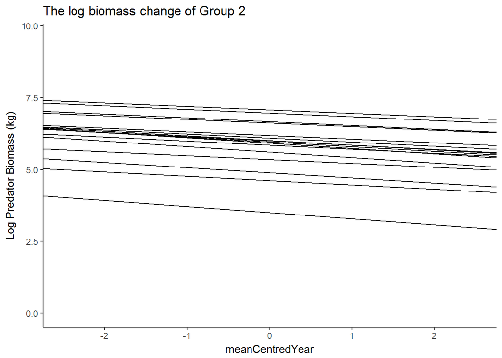

```r
#plot slopes of sites
bioMLog_Linesm <- coef(bioMLogm)$site[c(1:2)] # get slope and intercept of each line in model 3
names(bioMLog_Linesm) <- c("intercept", "slope")

m3.plotbm <- ggplot(data = FishDataTotm, aes(x = meanCentredYear, y = LogBiomass)) # plot of model with varying intercept but not slope, but only main slope shown
m3.plotbm + geom_blank() +
    theme_classic() +
    geom_abline(slope =bioMLog_Linesm$slope, intercept = bioMLog_Linesm$intercept) +
    labs(title="The log biomass change of Group 2", y = "Log Predator Biomass (kg)")
```

below is the plot not suing the mixed model results. It sies an lm function, and colours lines based on mean predation ranking

```r
head(FishDataTot)
```

```
##      site Year BiomasSiteSum BiomassSum meanYear meanCentredYear
## 1 Acono d 2011       1572.66       99.7   2013.5            -2.5
## 2 Acono d 2012        870.00      188.4   2013.5            -1.5
## 3 Acono d 2013       1599.30       55.0   2013.5            -0.5
## 4 Acono d 2014       1589.12      148.0   2013.5             0.5
## 5 Acono d 2015       1253.90      135.0   2013.5             1.5
## 6 Acono d 2016       1900.55      202.0   2013.5             2.5
##   LogBiomass
## 1   6.653920
## 2   7.565293
## 3   5.807355
## 4   7.219169
## 5   7.087463
## 6   7.665336
```

```r
predOrderm <- data.frame(FishDataTotm %>% #get the order of which sites are highest predation for plotting
  group_by(site) %>%
  summarise(meanbio = mean(BiomassSum)) %>%
  arrange(meanbio)%>%
  mutate(orderbio = c(1:16)))

plotNBioDatam <- merge(FishDataTotm, predOrderm, by = "site")

plotNBioDatam  <- plotNBioDatam[order(plotNBioDatam$orderbio),]
plotNBioDatam$reoderedSite <- reorder(plotNBioDatam$site, plotNBioDatam$orderbio)

getPalette <-  colorRampPalette(c("blue", "red"))
getPalette(16)
```

```
##  [1] "#0000FF" "#1100EE" "#2200DD" "#3300CC" "#4400BB" "#5500AA" "#660099"
##  [8] "#770088" "#880077" "#990066" "#AA0055" "#BB0044" "#CC0032" "#DD0021"
## [15] "#EE0010" "#FF0000"
```

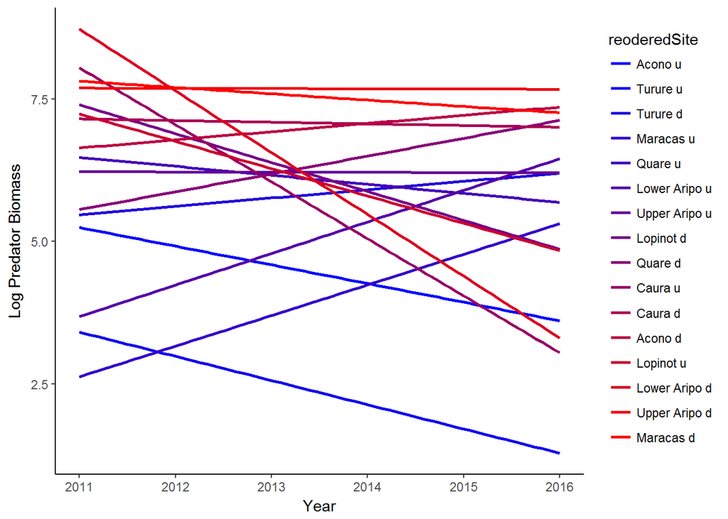

```r
NarrowAdundance <- ggplot(aes(x = Year, y = LogBiomass, colour = reoderedSite ),data = plotNBioDatam)
NarrowAdundance +
  geom_smooth(se = FALSE, method = "lm")+
    theme_classic()+
    labs(y = "Log Predator Biomass")   +
  scale_colour_manual(values = getPalette(16))
```

#Wide level predation definition

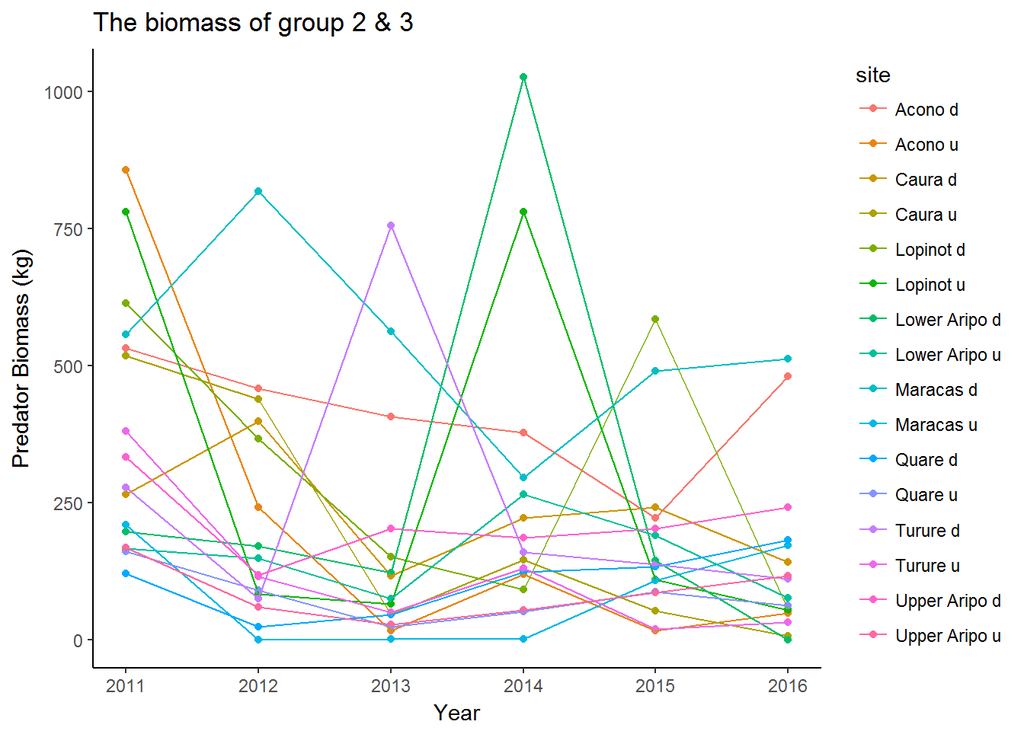

```r
BioPlotw <- ggplot(FishDataTotw, aes(x = Year, y = BiomassSum, col = site, group = site))
BioPlotw + geom_point() +
    geom_line() +
    theme_classic() +
    labs(title="The biomass of group 2 & 3", y = "Predator Biomass (kg)")
```

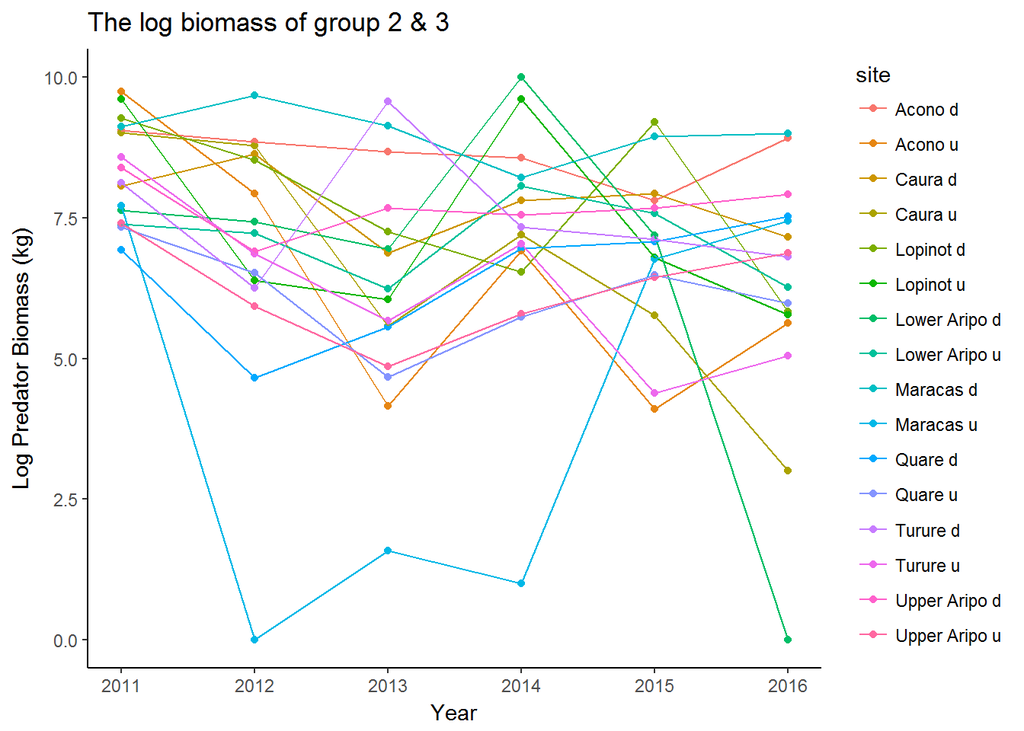

```r
BioPlotLogw <- ggplot(FishDataTotw, aes(x = Year, y = LogBiomass, col = site))
BioPlotLogw + geom_point() +
    geom_line() +
    theme_classic() +
    labs(title="The log biomass of group 2 & 3", y = "Log Predator Biomass (kg)")
```

Mixed model (wide)

```r
bioMLogw <- lmer(LogBiomass ~ meanCentredYear + (meanCentredYear|site), data = FishDataTotw)
summary(bioMLogw)
```

```
## Linear mixed model fit by REML ['lmerMod']
## Formula: LogBiomass ~ meanCentredYear + (meanCentredYear | site)
##    Data: FishDataTotw
##
## REML criterion at convergence: 387.4
##
## Scaled residuals:
##     Min      1Q  Median      3Q     Max
## -3.4977 -0.3802  0.0939  0.4813  2.1766
##
## Random effects:
##  Groups   Name            Variance Std.Dev. Corr
##  site     (Intercept)     0.92436  0.9614
##           meanCentredYear 0.05348  0.2313   -0.26
##  Residual                 2.56900  1.6028
## Number of obs: 96, groups:  site, 16
##
## Fixed effects:
##                 Estimate Std. Error t value
## (Intercept)       6.9707     0.2907  23.975
## meanCentredYear  -0.2768     0.1119  -2.474
##
## Correlation of Fixed Effects:
##             (Intr)
## meanCntrdYr -0.112
```

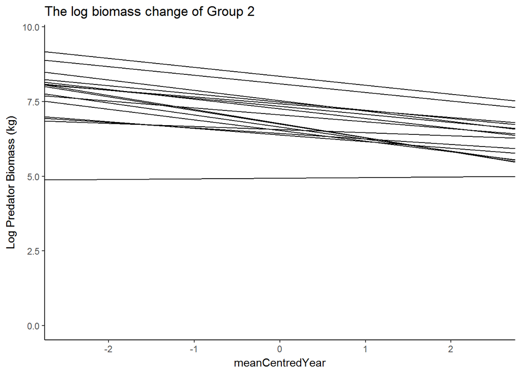

```r
#plot slopes of sites
bioMLog_Linesw <- coef(bioMLogw)$site[c(1:2)] # get slope and intercept of each line in model 3
names(bioMLog_Linesw) <- c("intercept", "slope")

m3.plotbw <- ggplot(data = FishDataTotw, aes(x = meanCentredYear, y = LogBiomass)) # plot of model with varying intercept but not slope, but only main slope shown
m3.plotbm + geom_blank() +
    theme_classic() +
    geom_abline(slope =bioMLog_Linesw$slope, intercept = bioMLog_Linesw$intercept) +
    labs(title="The log biomass change of Group 2", y = "Log Predator Biomass (kg)")
```

below is the plot not suing the mixed model results. It sies an lm function, and colours lines based on mean predation ranking

```r
head(FishDataTot)
```

```
##      site Year BiomasSiteSum BiomassSum meanYear meanCentredYear
## 1 Acono d 2011       1572.66       99.7   2013.5            -2.5
## 2 Acono d 2012        870.00      188.4   2013.5            -1.5
## 3 Acono d 2013       1599.30       55.0   2013.5            -0.5
## 4 Acono d 2014       1589.12      148.0   2013.5             0.5
## 5 Acono d 2015       1253.90      135.0   2013.5             1.5
## 6 Acono d 2016       1900.55      202.0   2013.5             2.5
##   LogBiomass
## 1   6.653920
## 2   7.565293
## 3   5.807355
## 4   7.219169
## 5   7.087463
## 6   7.665336
```

```r
predOrderw <- data.frame(FishDataTotw %>% #get the order of which sites are highest predation for plotting
  group_by(site) %>%
  summarise(meanbio = mean(BiomassSum)) %>%
  arrange(meanbio)%>%
  mutate(orderbio = c(1:16)))

plotNBioDataw <- merge(FishDataTotw, predOrderw, by = "site")

plotNBioDataw <- plotNBioDataw[order(plotNBioDataw$orderbio),]
plotNBioDataw$reoderedSite <- reorder(plotNBioDataw$site, plotNBioDataw$orderbio)

getPalette <-  colorRampPalette(c("blue", "red"))
getPalette(16)
```

```
##  [1] "#0000FF" "#1100EE" "#2200DD" "#3300CC" "#4400BB" "#5500AA" "#660099"
##  [8] "#770088" "#880077" "#990066" "#AA0055" "#BB0044" "#CC0032" "#DD0021"
## [15] "#EE0010" "#FF0000"
```

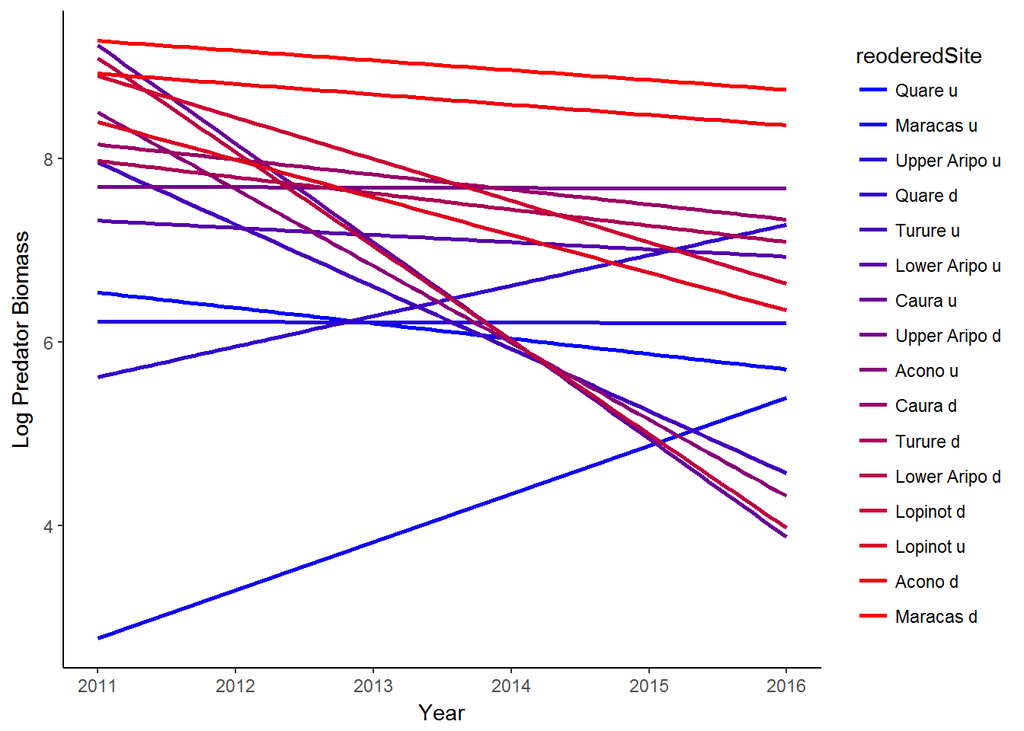

```r
NarrowAdundance <- ggplot(aes(x = Year, y = LogBiomass, colour = reoderedSite ),data = plotNBioDataw)
NarrowAdundance +
  geom_smooth(se = FALSE, method = "lm")+
    theme_classic()+
    labs(y = "Log Predator Biomass")   +
  scale_colour_manual(values = getPalette(16))
```